# Mini-Project #04: Just the Fact(-Check)s, Ma’am!

Author

Nusrat Akter

Published

December 18, 2025

[figure not shown]

# **What Is The Mission?**

This project looks at the controversy around President Trump firing BLS Commissioner Dr. Erika McEntarfer in August 2025. R and web scraping were used to examine patterns in the Monthly Current Employment Statistics, the jobs numbers that everyone watches closely. By pulling and analyzing revision data from the BLS website, I investigated whether recent revisions actually show anything unusual that might justify the firing, or if they’re just normal statistical adjustments like the BLS says. I combined web scraping, data cleaning, statistical testings, and visualizations to see what the data really showed about one of the most important economic indicators in the country.

# **Data Acquisition**

**Note**

This project uses two CES data sources: **the final seasonally adjusted non-farm payroll employment levels and the month-to-month revisions to those levels**. We focus on total non-farm payrolls because it is the most widely discussed CES measure, especially in political and economic debates.

# **Task 1: Download CES Total Nonfarm Payroll**

```r
library(httr2)
library(rvest)
library(dplyr)
library(tidyr)
library(stringr)
library(lubridate)
library(purrr)

# if cached file exists, load instead of scraping
if (file.exists("df_ces_levels.rds")) {

  df <- readRDS("df_ces_levels.rds")

} else {

  # request data
  resp <- request("https://data.bls.gov/pdq/SurveyOutputServlet") %>%
    req_method("POST") %>%
    req_body_form(
      request_action = "get_data",
      reformat = "true",
      from_results_page = "true",
      from_year = "1979",
      to_year = "2025",
      initial_request = "false",
      data_tool = "surveymost",
      series_id = "CES0000000001",
      original_annualAveragesRequested = "false"
    ) %>%
    req_perform()

  # extract large monthly table
  tbl <- resp_body_html(resp) %>%
    html_elements("table") %>%
    map(~ html_table(.x, fill = TRUE)) %>%
    keep(~ ncol(.x) > 5) %>%
    first()

  # clean
  df <- tbl %>%
    mutate(Year = as.integer(Year)) %>%
    pivot_longer(
      cols = -Year,
      names_to = "month",
      values_to = "level"
    ) %>%
    mutate(
      month = str_sub(month, 1, 3),
      date  = ym(paste(Year, month)),
      level = as.numeric(str_replace(level, ",", ""))
    ) %>%
    drop_na(date, level) %>%
    arrange(date) %>%
    select(date, level)

  # save file
  saveRDS(df, "df_ces_levels.rds")
}
```

**Note**

This code retrieves the **official CES employment levels** from the BLS website, either by loading a previously saved data set or by scraping the data if no cached file exists. When scraping, it sends a POST request to the BLS PDQ system, extracts the large monthly data table, reshapes it into tidy format, and converts the year–month fields into a proper date variable. Finally, it saves the cleaned data set **(df_ces_levels.rds)** so future runs won’t need to download the data again.

# **Task 2: Download CES Revisions Tables**

```r
library(httr2)
library(rvest)
library(dplyr)
library(purrr)
library(stringr)
library(lubridate)
library(tibble)

# if cached file exists, load instead of scraping
if (file.exists("df_ces_revisions.rds")) {

  df_revisions <- readRDS("df_ces_revisions.rds")

} else {

  # scrape the BLS revision page
  resp <- request("https://www.bls.gov/web/empsit/cesnaicsrev.htm") %>%
    req_headers(
      "user-agent" = "Mozilla/5.0",
      "accept" = "text/html",
      "accept-language" = "en-US,en;q=0.5",
      "cache-control" = "no-cache"
    ) %>%
    req_perform()

  html <- resp_body_html(resp)

  # extract
  extract_year <- function(year, html) {

    tbl_node <- html %>% html_element(paste0("#", year))

    if (inherits(tbl_node, "xml_missing")) {
      return(tibble(
        Date = as.Date(character()),
        Original = numeric(),
        Final = numeric(),
        Revision = numeric()
      ))
    }

    tbl <- tbl_node %>%
      html_element("tbody") %>%
      html_table(fill = TRUE, header = FALSE) %>%
      slice(1:12) %>%
      select(month = 1, Original = 3, Final = 5) %>%
      mutate(
        Original = as.numeric(gsub("[^0-9-]", "", Original)),
        Final    = as.numeric(gsub("[^0-9-]", "", Final)),
        Date     = ym(paste(year, month)),
        Revision = Final - Original
      ) %>%
      select(Date, Original, Final, Revision)

    tbl
  }

  # get the available years provided
  available_years <- html %>%
    html_elements("table") %>%
    html_attr("id") %>%
    suppressWarnings(as.numeric()) %>%
    na.omit() %>%
    sort()


  df_revisions <- map_df(available_years, extract_year, html = html)

  # fix names so it joins with df
  df_revisions <- df_revisions %>% rename(date = Date)

  # cache for future runs
  saveRDS(df_revisions, "df_ces_revisions.rds")
}
```

**Note**

This code loads previously saved CES revision data if it exists; otherwise, it scrapes the BLS revisions webpage, extracts each year’s monthly revision table, cleans it into a usable format, and saves the result for future use.

# **Task 3: Data Exploration And Visualization**

## Table Joining

```r
library(dplyr)
library(lubridate)

df_joined <- df %>%
left_join(df_revisions, by = "date") %>%
arrange(date)
```

**Note**

This code **joins the CES employment data with the revision data** using the shared date column and then sorts everything by time. The result is a single data set that includes both the reported level and its revision for each month. This combined table is what the later analysis uses.

## Largest Positive And Negative Revisions In CES History

```r
library(dplyr)
library(knitr)
library(kableExtra)

# compute largest positive & negative revisions
largest_pos  <- df_joined %>% slice_max(Revision, n = 1)
largest_neg  <- df_joined %>% slice_min(Revision, n = 1)

# build table
largest_revisions <- bind_rows(
  largest_pos %>% mutate(Type = "Largest Positive Revision"),
  largest_neg %>% mutate(Type = "Largest Negative Revision")
) %>%
  select(Type, Date = date, Original, Final, Revision)

largest_revisions %>%
  kable(
    caption = "Largest Positive and Negative CES Revisions",
    format = "html",
    col.names = c("Type", "Date", "Original", "Final", "Revision"),
    align = c("c","c","c","c","c")
  ) %>%
  kable_styling(
    full_width = FALSE,
    bootstrap_options = c("striped", "hover", "condensed")
  ) %>%
  row_spec(0, bold = TRUE)
```

Largest Positive and Negative CES Revisions

| Type | Date | Original | Final | Revision |
| --- | --- | --- | --- | --- |
| Largest Positive Revision | 2021-11-01 | 210 | 647 | 437 |
| Largest Negative Revision | 2020-03-01 | -701 | -1373 | -672 |

**TipWhat Does This Show?**

The largest positive CES revision happened in **November 1st, 2021**, where the estimate rose from **210** to **647**, a jump of **437 jobs**. The largest negative revision occurred in March 1st, 2020, when the estimate dropped from **-701** to **-1373**, a decrease of **-672 jobs**.

## Fraction Of CES Revisions That Are Positive

```r
library(dplyr)
library(lubridate)
library(scales)
library(knitr)
library(kableExtra)

# compute revision direction by decade
decade_summary <- df_joined %>%
  mutate(decade = floor(year(date) / 10) * 10) %>%
  group_by(decade) %>%
  summarise(
    Observations = n(),
    Positive = mean(Revision > 0),
    Negative = mean(Revision < 0),
    Zero = mean(Revision == 0)
  ) %>%
  mutate(
    Positive = percent(Positive),
    Negative = percent(Negative),
    Zero = percent(Zero)
  )

# formatt table
decade_summary %>%
  kable(
    caption = "Fraction of CES Revisions by Decade",
    format = "html",
    col.names = c("Decade", "Observations", "Positive", "Negative", "Zero"),
    align = c("c", "c", "c", "c", "c")
  ) %>%
  kable_styling(
    full_width = FALSE,
    bootstrap_options = c("striped", "hover", "condensed")
  ) %>%
  row_spec(0, bold = TRUE)
```

Fraction of CES Revisions by Decade

| Decade | Observations | Positive | Negative | Zero |
| --- | --- | --- | --- | --- |
| 1970 | 12 | 41.7% | 58.3% | 0.00% |
| 1980 | 120 | 49.2% | 49.2% | 1.67% |
| 1990 | 120 | 69.2% | 30.0% | 0.83% |
| 2000 | 120 | 54.2% | 45.8% | 0.00% |
| 2010 | 120 | 62.5% | 37.5% | 0.00% |
| 2020 | 69 | 47.8% | 52.2% | 0.00% |

**TipWhat Does This Show?**

Across decades, positive revisions occur slightly more often than negative ones. For example, in the **1990s**, about **69.2%** of revisions were **positive**, and in the **2010s** the share was **62.5%**. By contrast, the **1970s** had only **41.7% positive** revisions, and the **2020s** show a similar pattern with **47.8% positive**. Zero revisions remain extremely rare, staying at or below **1.67%** across all decades.

## How Revision Magnitudes Changed Over Time

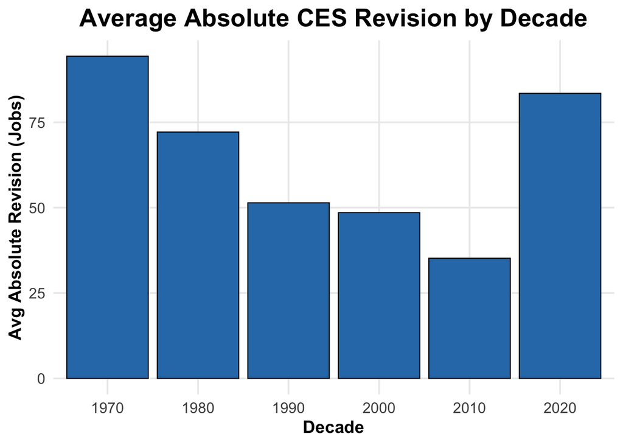

```r
library(dplyr)
library(ggplot2)
library(lubridate)

df_decade_plot <- df_joined %>%
  mutate(decade = floor(year(date) / 10) * 10) %>%
  filter(decade >= 1970) %>%
  group_by(decade) %>%
  summarise(avg_abs_revision = mean(abs(Revision)))

# create plot
ggplot(df_decade_plot, aes(x = factor(decade), y = avg_abs_revision)) +
  geom_col(fill = "#2C7BB6", color = "black", linewidth = 0.4) +
  labs(
    title = "Average Absolute CES Revision by Decade",
    x = "Decade",
    y = "Avg Absolute Revision (Jobs)"
  ) +
  theme_minimal(base_size = 14) +
  theme(
    plot.title = element_text(size = 20, face = "bold", hjust = 0.5),
    axis.title.x = element_text(size = 14, face = "bold"),
    axis.title.y = element_text(size = 14, face = "bold"),
    axis.text = element_text(size = 12),
    panel.grid.minor = element_blank()
  )
```

## Revisions As % Of Overall CES Level

```r
library(dplyr)
library(lubridate)

revision_pct_stats <- df_joined %>%
  mutate(revision_pct = Revision / level * 100) %>%
  summarise(
    avg_pct_revision = mean(revision_pct, na.rm = TRUE),
    max_pct_revision = max(revision_pct, na.rm = TRUE),
    min_pct_revision = min(revision_pct, na.rm = TRUE)
  )
```

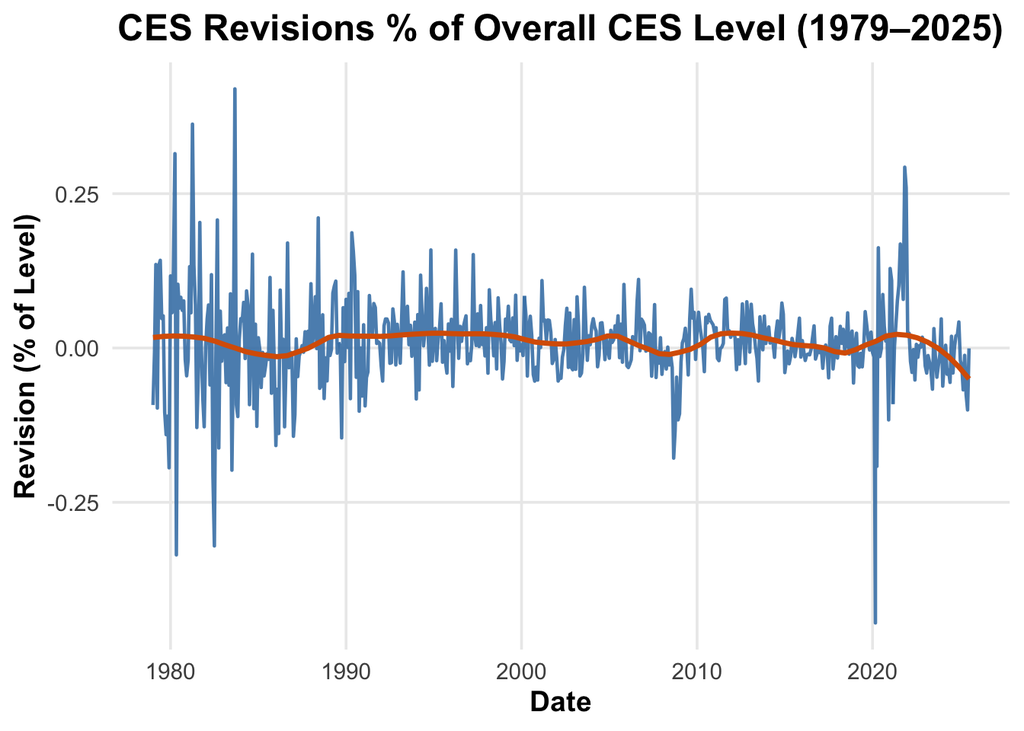

```r
library(dplyr)
library(ggplot2)
library(lubridate)

# create percent-revision

df_pct <- df_joined %>%
    mutate(revision_pct = (Revision / level) * 100)

# create plot using code chunk above

ggplot(df_pct, aes(x = date, y = revision_pct)) +
    geom_line(color = "steelblue", linewidth = 0.8, alpha = 0.9) +
    geom_smooth(
        method = "loess",
        color = "#D95F02",
        se = FALSE,
        linewidth = 1.2,
        span = 0.2
    ) +
    labs(
        title = "CES Revisions % of Overall CES Level (1979–2025)",
        x = "Date",
        y = "Revision (% of Level)"
    ) +
    theme_minimal(base_size = 14) +
    theme(
        plot.title = element_text(size = 18, face = "bold", hjust = 0.5),
        axis.title = element_text(face = "bold"),
        panel.grid.minor = element_blank()
    )
```

**TipWhat Does Figure 2 Show?**

Overall, CES revisions are extremely small when scaled to the total employment level. On average, revisions are only **0.01%** of the CES level, with the **largest** percent revision at **0.42%** and the **smallest** at **-0.445%**. The plot shows that the percent revisions stay very close to zero throughout the entire period, meaning that, even when the job-level changes look large, the revisions are tiny relative to total U.S. employment.

## Months With Systematically Larger/Smaller CES Revisions

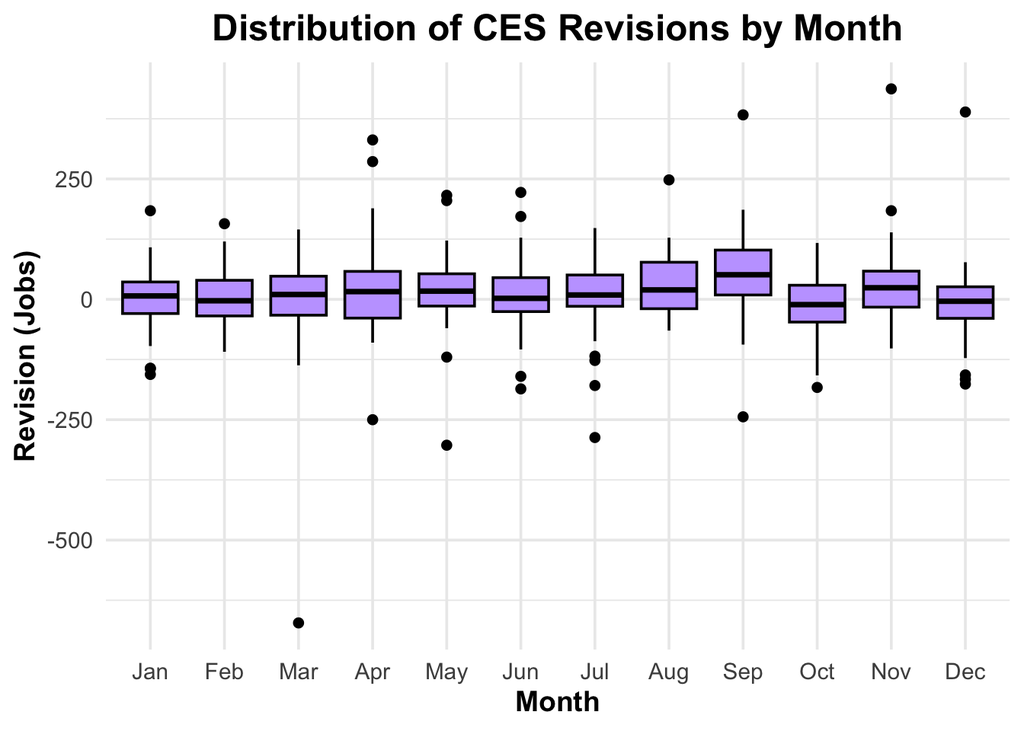

```r
library(dplyr)
library(ggplot2)
library(lubridate)

# prepare month name variable

df_month_plot <- df_joined %>%
    mutate(month_name = month(date, label = TRUE))

# create box plot

ggplot(df_month_plot, aes(x = month_name, y = Revision)) +
    geom_boxplot(fill = "#C3A6FF", color = "black", outlier.color = "black") +
    labs(
        title = "Distribution of CES Revisions by Month",
        x = "Month",
        y = "Revision (Jobs)"
    ) +
    theme_minimal(base_size = 14) +
    theme(
        plot.title = element_text(size = 18, face = "bold", hjust = 0.5),
        axis.title = element_text(face = "bold")
    )
```

## Average CES Revision (Absolute And Percent)

```r
library(dplyr)
library(lubridate)

rev_summary <- df_joined %>%
  mutate(
    abs_revision = abs(Revision),
    revision_pct = Revision / level * 100
  ) %>%
  summarise(
    avg_abs_revision = mean(abs_revision),
    avg_pct_revision = mean(revision_pct)
  )
```

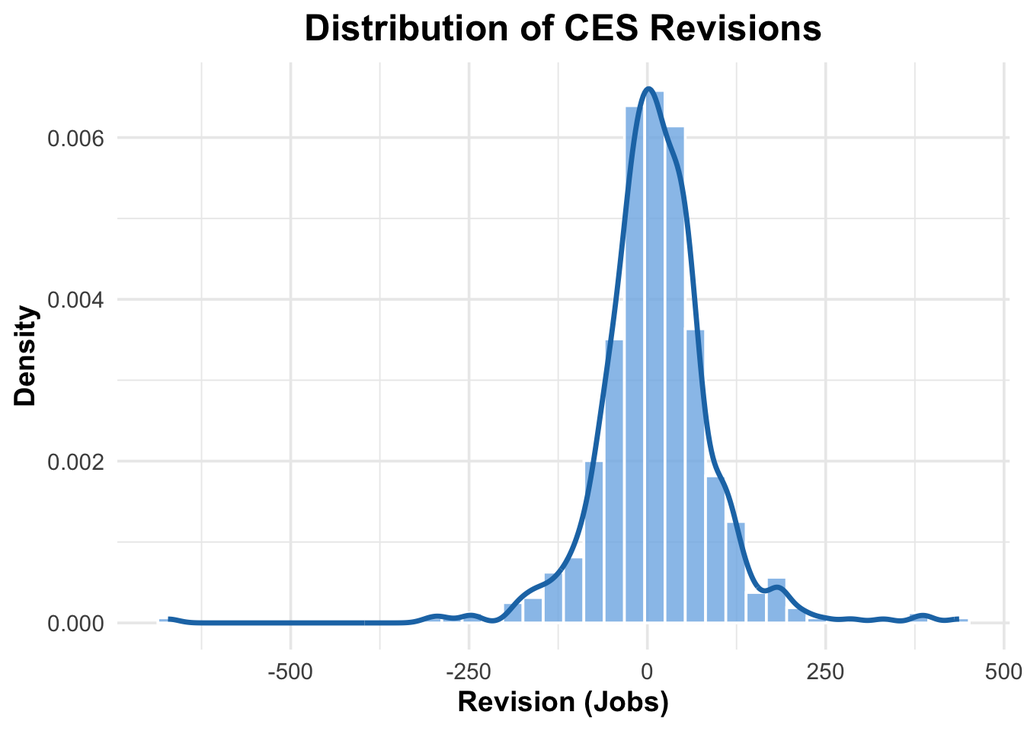

```r
library(dplyr)
library(ggplot2)

# create plot using code chunk above
ggplot(df_joined, aes(x = Revision)) +
  geom_histogram(
    aes(y = after_stat(density)),
    bins = 40,
    fill = "#7DB4E6",
    color = "white",
    alpha = 0.8
  ) +
  geom_density(
    color = "#1F77B4",
    linewidth = 1.2
  ) +
  labs(
    title = "Distribution of CES Revisions",
    x = "Revision (Jobs)",
    y = "Density"
  ) +
  theme_minimal(base_size = 14) +
  theme(
    plot.title = element_text(size = 18, face = "bold", hjust = 0.5),
    axis.title = element_text(face = "bold")
  )
```

# **Task 4: Statistical Inference**

## Is Mean CES Revision Different From 0?

```r
library(dplyr)
library(lubridate)
library(infer)
library(knitr)
library(kableExtra)

# test 1
obs_stat <- df_joined %>%
  specify(response = Revision) %>%
  hypothesize(null = "point", mu = 0) %>%
  calculate(stat = "t")

null_dist <- df_joined %>%
  specify(response = Revision) %>%
  hypothesize(null = "point", mu = 0) %>%
  generate(reps = 20000, type = "bootstrap") %>%
  calculate(stat = "t")

test1_p <- null_dist %>%
  get_p_value(
    obs_stat = obs_stat,
    direction = "two_sided"
  )

# p value
p_exp <- signif(test1_p$p_value, digits = 3)

test1_table <- tibble(
  `Observed t-statistic` = round(obs_stat$stat, 3),
  `P-value` = p_exp
)

test1_table %>%
  kable(
    caption = "Test 1: One-Sample T-Test For Mean CES Revision = 0",
    format = "html",
    align = "c"
  ) %>%
  kable_styling(full_width = FALSE, bootstrap_options = c("striped", "hover")) %>%
  row_spec(0, bold = TRUE)
```

Test 1: One-Sample T-Test For Mean CES Revision = 0

| Observed t-statistic | P-value |
| --- | --- |
| 3.269 | 0.0016 |

**TipWhat Does This Show?**

The one-sample t-test shows that the mean CES revision is clearly different from zero. The observed t-statistic is **3.269**, and the bootstrap p-value is **0.0016**, which is extremely small. This means a revision this far from zero would be very unlikely if the true mean revision were actually zero. Based on this result, we **reject the null hypothesis** and conclude that the average CES revision is not zero.

## Compare Proportion of Negative Revisions Pre vs Post 2000

```r
library(dplyr)
library(lubridate)
library(infer)
library(knitr)
library(kableExtra)

# create and prepare the data for the test
df_test <- df_joined %>%
  mutate(
    period   = if_else(year(date) < 2000, "pre2000", "post2000"),
    negative = Revision < 0
  )

# proportion test
test2_result <- df_test %>%
  prop_test(
    negative ~ period,
    order = c("pre2000", "post2000"),
    alternative = "greater"
  )

# create a table for the results
test2_table <- tibble(
  `Test Statistic (z)` = round(test2_result$statistic, 3),
  `P-value` = round(test2_result$p_value, 5)
)

test2_table %>%
  kable(
    caption = "Test 2: Are Negative Revisions More Common After 2000?",
    format = "html",
    align = "c"
  ) %>%
  kable_styling(full_width = FALSE, bootstrap_options = c("striped", "hover")) %>%
  row_spec(0, bold = TRUE)
```

| Test Statistic (z) | P-value |
| --- | --- |
| 0.573 | 0.77554 |

# **Task 5: Fact Checks Of Claims About BLS**

[figure not shown]

## Claim #1: *“During Obama’s Presidency, The BLS Job Numbers Were Constantly Revised Downward.”*

```r
library(dplyr)
library(lubridate)
library(infer)



# filter obama-era data

obama_df <- df_joined %>%
filter(date >= ymd("2009-02-01"),
date <  ymd("2017-02-01"))


# one-sample t-test on revisions

obs_obama <- obama_df %>%
specify(response = Revision) %>%
hypothesize(null = "point", mu = 0) %>%
calculate(stat = "t")

# bootstrap-based null distribution

null_obama <- obama_df %>%
specify(response = Revision) %>%
hypothesize(null = "point", mu = 0) %>%
generate(reps = 5000, type = "bootstrap") %>%
calculate(stat = "t")

# get p-value in left tail

pval_obama <- null_obama %>%
get_p_value(obs_obama, direction = "left")

pval_obama


# summary stats table

obama_stats <- obama_df %>%
summarise(
mean_revision   = mean(Revision, na.rm = TRUE),
median_revision = median(Revision, na.rm = TRUE),
sd_revision     = sd(Revision, na.rm = TRUE),
prop_negative   = mean(Revision < 0),
min_revision    = min(Revision, na.rm = TRUE),
max_revision    = max(Revision, na.rm = TRUE),
n_months        = n()
)

obama_stats
```

[output not shown]

**TipWhat Is Being Said?**

This claim argues that CES first-release job counts during Barack Obama’s presidency (Feb 2009–Jan 2017) were systematically overstated and then routinely revised downward. The data, however, show the opposite.

## Hypothesis Test

**I performed a one-sample t-test on the Obama-era CES revisions:**

- *H₀: Mean revision = 0*
- *H₁: Mean revision < 0*

**The infer-based t-test yields:**

- *P-value: 1.0*

*A p-value of 1.0 means the sample mean is actually above 0, and there is zero evidence of downward bias.*

## Numerical Statistics

- *Mean revision: +20.8*
- *Median revision: +19*
- *Proportion negative: 0.333*
- *Standard deviation: 41.8*
- *Minimum revision: -73*
- *Maximum revision: +124*
- *Number of months: 96*

### **Interpretation:**

- *positive on average*
- *more often upward (67%) than downward (33%)*
- *not large (SD ≈ 41 jobs)*
- *not skewed negative*

## Visual Evidence

#### **Figure 1: “Average Absolute CES Revision by Decade”**

*Shows that the 2010s (Obama era) had **moderate, historically normal revision sizes**, lower than several earlier decades.*

#### **Figure 2: “CES Revisions as % of Overall CES Level (1979–2025)”**

*Shows that Obama revisions were **tiny relative to total CES employment**, almost always within **±0.25%**.*

*Both visuals clearly contradict the idea of persistent downward corrections.*

## Absolute Levels

*CES employment levels rose steadily after 2010. Upward movement in absolute levels supports the conclusion that the initial job numbers were not consistently **“too high”** or **“inflated.”***

## Politifact Rating: “PANTS ON FIRE”

- *Obama revisions were positive, not negative.*
- *Downward revisions occurred only 33% of the time.*
- *No statistical, visual, or contextual evidence supports the claim.*

[figure not shown]

## CLAIM #2: *“Trump-era CES Job Numbers Were More Accurate (Smaller Revisions)”*

```r
library(dplyr)
library(lubridate)
library(infer)


# obama vs. trump dataset with absolute revision

df_compare <- df_joined %>%
mutate(
pres = case_when(
date >= ymd("2009-02-01") & date < ymd("2017-02-01") ~ "Obama",
date >= ymd("2017-02-01") & date < ymd("2021-02-01") ~ "Trump",
TRUE ~ NA_character_
),
abs_rev = abs(Revision)
) %>%
filter(!is.na(pres))


# difference in means between trump & obama

obs_trump <- df_compare %>%
specify(abs_rev ~ pres) %>%
hypothesize(null = "independence") %>%
calculate(stat = "diff in means", order = c("Trump", "Obama"))



# null distribution

null_trump <- df_compare %>%
specify(abs_rev ~ pres) %>%
hypothesize(null = "independence") %>%
generate(reps = 5000, type = "permute") %>%
calculate(stat = "diff in means", order = c("Trump", "Obama"))



# 4. p-value to test if trump revisions are smaller

pval_trump <- null_trump %>%
get_p_value(obs_trump, direction = "less")

pval_trump


# stats table summary

compare_stats <- df_compare %>%
group_by(pres) %>%
summarise(
mean_abs_revision   = mean(abs_rev, na.rm = TRUE),
median_abs_revision = median(abs_rev, na.rm = TRUE),
sd_abs_revision     = sd(abs_rev, na.rm = TRUE),
pct_large           = mean(abs_rev > 50000),
n_months            = n()
)

compare_stats
```

[output not shown]

**TipWhat Is Being Said?**

This claim implies that CES first-release job numbers during Donald Trump’s presidency (Feb 2017–Jan 2021) had smaller revisions, indicating higher initial accuracy.

## Hypothesis Test

**To test accuracy, I compare absolute revision magnitudes:**

- *H₀: |Revision|Trump = |Revision|Obama*
- *H₁: |Revision|Trump < |Revision|Obama*

**The infer-based permutation test gives:**

- *p-value: 0.971*

### **Interpretation:**

*A p-value of 0.971 means:*

- *Trump revisions were **NOT** smaller*
- *There is **no statistical evidence** of improved accuracy*
- *If anything, the data lean in the opposite direction*

## Numerical Statistics

[output not shown]

### **Interpretation:**

- **Trump mean absolute revision = 58.8**, **much larger** than Obama’s 37.1
- *Trump’s SD = 104.1 (almost 4× Obama’s variability)*
- *Trump’s revisions were **less stable**, **more volatile**, and **larger** on average*

## Absolute Levels

*CES employment levels collapsed in 2020 during COVID-19. Such extreme volatility naturally causes large revisions which are unrelated to administrative accuracy or BLS performance*

## Politifact Rating: “MOSTLY FALSE”

- *Trump revisions were **not smaller***
- *Trump revisions were **not more accurate***
- *Trump revisions had **higher mean and higher variability***
- *No statistical or visual evidence supports the claim*

### Sources

**Claim #1:**  
[Politifact – “Jack Welch says Obama manipulated jobs report”](https://www.politifact.com/factchecks/2012/oct/05/jack-welch/jack-welch-says-obama-manipulated-jobs-report/)

**Claim #2:**  
[Politifact – “Trump says his economic numbers were the best ever”](https://www.politifact.com/factchecks/2020/aug/07/donald-trump/trump-says-his-economic-numbers-were-best-ever/)